# Churn Anaysis -- Step2 Predict the Churn

This section will focus on the predictive modelings. The first step to understand the dataset can be found at: https://hehehe.shinyapps.io/Churn_Step1_/.

Before staring, a quick recall to previous analysis.

From the intutive visulization analysis, we knew that **Contract**, **tenure** and **Total/Monthly Charges** will effect Churn of customer. So here, we would like appling some classification models to **validate and quantify** the relationships between independent features and our Target(Churn).

### Key Conclusions

- Baseline Model(Logistic Regression):
  - Accuracy : 79.18% |AUC Score: 71.01% |F1 Score : 57.84%
- Other Models best one (XGboost tuned):
  - Accuracy : 80.24% |AUC Score: 72.07% |F1 Score : 59.59%
- Final Model(XGboost weighted):
  - Accuracy : **78.89%** |AUC Score: **73.52%** |F1 Score : **61.07%**

Consider about the business question, we should not only care about the accuracy of the model but also the Precision and Recall(Sensitivity).

```
- Precision: Of all the customers that we predicted as Churned, how many actually Churned?
- Recall(Sensitivity): Of all the customers that truly Churned, how many actually predicted as Churned?
- F1 score: F1 Score is the weighted average of Precision and Recall.
```

Here in this situation, **the cost of false positive is lower than false negative.** Which means that if a customer is actully churned, but the model predict it as Non-churned, it will be **more harmful to the revenue** than if a customer is actully Non-churned, but we predict it as Churned.

### More Improvements

I belive that there are still a lot of things can be done, such as:

- **Get more data for modeling(only 7K in this dataset)**
- **There are still lots of other popular classification models can be tried**
- **Breakdown the dataset into different groups, for example, applied models on each contract group separately to see performance**
- **Ensemble the weak classifications together to get better result**

### Useful Reference Links

- https://www.kaggle.com/pavanraj159/telecom-customer-churn-prediction#5.-Model-Building
- https://www.ritchieng.com/machine-learning-evaluate-classification-model/
- https://www.kaggle.com/nirajvermafcb/comparing-various-ml-models-roc-curve-comparison
- https://blog.exsilio.com/all/accuracy-precision-recall-f1-score-interpretation-of-performance-measures/
- https://www.analyticsvidhya.com/blog/2016/03/complete-guide-parameter-tuning-xgboost-with-codes-python/

### Data Clean and Preprocess

### 1. Import the dataset and clean

#### 1.1 Import the necessary libs

```python
import pandas as pd
import numpy as np
import matplotlib.pyplot as plt
import seaborn as sns
import sklearn.preprocessing as preprocessing
from sklearn import linear_model
#from sklearn.cross_validation import cross_validation
import sklearn.model_selection
from sklearn import svm
from sklearn.ensemble import RandomForestClassifier
from sklearn.ensemble import GradientBoostingClassifier
from sklearn.model_selection import learning_curve
#from sklearn.grid_search import GridSearchCV
from sklearn.metrics import explained_variance_score
from sklearn.feature_extraction import DictVectorizer
from sklearn.model_selection import train_test_split
from sklearn.metrics import confusion_matrix
from sklearn.metrics import accuracy_score
from sklearn.metrics import classification_report
from sklearn import metrics
from sklearn.feature_selection import RFE
from sklearn.preprocessing import StandardScaler
from sklearn.model_selection import RandomizedSearchCV, GridSearchCV,ShuffleSplit
from sklearn.model_selection import StratifiedKFold
from sklearn.metrics import roc_auc_score, precision_recall_curve, roc_curve, auc, average_precision_score
from xgboost import XGBClassifier
%matplotlib inline
import warnings
warnings.filterwarnings("ignore")
#!pip install plotly
import json, urllib
import plotly.plotly as py
from plotly.offline import plot
```

#### 1.2 Import the dataset

```python
datapath = r'C:\Users\hes0\Documents\Sixuan\Projects\2019Q3\Churn\Data'.replace("\\",'/')
data = pd.read_csv(datapath+'/churn.csv',sep = ',', header = 0)
data.head()
```

|  | customerID | gender | SeniorCitizen | Partner | Dependents | tenure | PhoneService | MultipleLines | InternetService | OnlineSecurity | ... | DeviceProtection | TechSupport | StreamingTV | StreamingMovies | Contract | PaperlessBilling | PaymentMethod | MonthlyCharges | TotalCharges | Churn |
| --- | --- | --- | --- | --- | --- | --- | --- | --- | --- | --- | --- | --- | --- | --- | --- | --- | --- | --- | --- | --- | --- |
| 0 | 7590-VHVEG | Female | 0 | Yes | No | 1 | No | No phone service | DSL | No | ... | No | No | No | No | Month-to-month | Yes | Electronic check | 29.85 | 29.85 | No |
| 1 | 5575-GNVDE | Male | 0 | No | No | 34 | Yes | No | DSL | Yes | ... | Yes | No | No | No | One year | No | Mailed check | 56.95 | 1889.5 | No |
| 2 | 3668-QPYBK | Male | 0 | No | No | 2 | Yes | No | DSL | Yes | ... | No | No | No | No | Month-to-month | Yes | Mailed check | 53.85 | 108.15 | Yes |
| 3 | 7795-CFOCW | Male | 0 | No | No | 45 | No | No phone service | DSL | Yes | ... | Yes | Yes | No | No | One year | No | Bank transfer (automatic) | 42.30 | 1840.75 | No |
| 4 | 9237-HQITU | Female | 0 | No | No | 2 | Yes | No | Fiber optic | No | ... | No | No | No | No | Month-to-month | Yes | Electronic check | 70.70 | 151.65 | Yes |

5 rows × 21 columns

```python
data.info()
```

```
<class 'pandas.core.frame.DataFrame'>
RangeIndex: 7043 entries, 0 to 7042
Data columns (total 21 columns):
customerID          7043 non-null object
gender              7043 non-null object
SeniorCitizen       7043 non-null int64
Partner             7043 non-null object
Dependents          7043 non-null object
tenure              7043 non-null int64
PhoneService        7043 non-null object
MultipleLines       7043 non-null object
InternetService     7043 non-null object
OnlineSecurity      7043 non-null object
OnlineBackup        7043 non-null object
DeviceProtection    7043 non-null object
TechSupport         7043 non-null object
StreamingTV         7043 non-null object
StreamingMovies     7043 non-null object
Contract            7043 non-null object
PaperlessBilling    7043 non-null object
PaymentMethod       7043 non-null object
MonthlyCharges      7043 non-null float64
TotalCharges        7043 non-null object
Churn               7043 non-null object
dtypes: float64(1), int64(2), object(18)
memory usage: 1.1+ MB
```

#### 1.3 Check the missing values

- Convert thhe 'TotalCharges' from character to numeric(float)
- Check/Delete the missing rows (already knew the low rate of missing in Step1 and decide to delete)

```python
print('Total Rows and columns before removing missing:')
print ("Rows     : " ,data.shape[0])
print ("Columns  : " ,data.shape[1])
print('-----------------------------------------------------------------------------------------------------------------------')
#Replace spaces with null in TotalCharges
data['TotalCharges'] =  data['TotalCharges'].replace(" ", np.nan)
#Check for missing values
n_missing = data[data['TotalCharges'].isnull()].shape[0]
percent_missing = round(data[data['TotalCharges'].isnull()].shape[0]/data.shape[0]*100,2)
print('Missing check for TotalCharges: ')
print("There are", n_missing, 'records contains missing values, which is', percent_missing, '% of whole dataset')
print('-----------------------------------------------------------------------------------------------------------------------')
#Removing the 11 missing records
data = data[data['TotalCharges'].notnull()]
#Reset the index after dropna (to aviod confusion for scaling merge)
data.reset_index(drop=True, inplace=True)
print('Total Rows and columns after removing missing:')
print ("Rows     : " ,data.shape[0])
print ("Columns  : " ,data.shape[1])
```

```
Total Rows and columns before removing missing:
Rows     :  7043
Columns  :  21
-----------------------------------------------------------------------------------------------------------------------
Missing check for TotalCharges:
There are 11 records contains missing values, which is 0.16 % of whole dataset
-----------------------------------------------------------------------------------------------------------------------
Total Rows and columns after removing missing:
Rows     :  7032
Columns  :  21
```

### 2. Preprocess the dataset for modeling

**2.1 Create numerical features into catagorical buckets**

[output not shown]

```python
#Convert the TotalCharges from character into numeric
data["TotalCharges"] = data["TotalCharges"].astype(float)
#data['Total'] = pd.to_numeric(data['TotalCharges'], errors='coerce')

#Create numeric bucket
#1. tenure_group
def tenure_group_fun(x):
    if x['tenure'] <= 12:
        return 'tenure_group1'
    if x['tenure'] <= 24:
        return 'tenure_group2'
    if x['tenure'] <= 36:
        return 'tenure_group2'
    if x['tenure'] <= 48:
        return 'tenure_group3'
    if x['tenure'] <= 60:
        return 'tenure_group4'
    if x['tenure'] <= 72:
        return 'tenure_group5'

data['tenure_group'] = data.apply(tenure_group_fun, axis = 1)

#2. MonthlyCharge cut by quantile into 4 group
bin_labels = ['monthly_Q1', 'monthly_Q2', 'monthly_Q3', 'monthly_Q4']
data['monthly_group'] = pd.qcut(data['MonthlyCharges'], q=[0, .25, .5, .75, 1], labels=bin_labels)

#3. TotalCharge cut by quantile into 4 group
bin_labels = ['total_Q1', 'total_Q2', 'total_Q3', 'total_Q4']
data['total_group'] = pd.qcut(data['TotalCharges'], q=[0, .25, .5, .75, 1], labels=bin_labels)
```

```
Test the tenure_group after cutting:
-----------------------------------------------------------------------------------------------------------------------
The bucketed new group summary:
               Count      %
tenure_group1   2175  30.93
tenure_group2   1856  26.39
tenure_group3    762  10.84
tenure_group4    832  11.83
tenure_group5   1407  20.01
-----------------------------------------------------------------------------------------------------------------------
The bucketd new group bar chart:
```

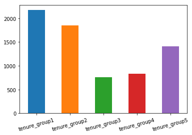

```python
print('Test the tenure_group after cutting:')
print('-----------------------------------------------------------------------------------------------------------------------')
def view_group(input_dataframe, view_feature):
    c = input_dataframe[view_feature].value_counts()
    p = round(input_dataframe[view_feature].value_counts(normalize = True)*100, 2)
    combine = pd.concat([c,p], axis = 1, keys = ['Count', '%']).sort_index()
    print('The bucketed new group summary: ')
    print(combine)
    print('-----------------------------------------------------------------------------------------------------------------------')
    print('The bucketd new group bar chart:')
    figure = plt.figure()
    input_dataframe[view_feature].value_counts().sort_index().plot(kind = 'bar')
    plt.xticks(rotation=15)
    plt.show()

view_group(data, 'tenure_group')
```

#### 2.2 Understand and separte columns by type

```python
#Separating catagorical and numerical columns
Id_col     = ['customerID']
target_col = ['Churn']
cat_cols   = data.nunique()[data.nunique() < 6].keys().tolist()
cat_cols   = [x for x in cat_cols if x not in target_col]

#Split catagorical columns into Binary and Multiple
cat_bin_cols   = data.drop(columns = ['Churn']).nunique()[data.drop(columns = ['Churn']).nunique() ==2].keys().tolist()
cat_mul_cols   = [x for x in cat_cols if x not in cat_bin_cols]

num_cols   = [x for x in data.columns if x not in cat_cols + target_col + Id_col]
print('The ID column is ', Id_col)
print('-----------------------------------------------------------------------------------------------------------------------')
print('The Target column is ', target_col)
print('-----------------------------------------------------------------------------------------------------------------------')
print('The 16 + 3(created) Catagorical columns:')
print('Where binary categorical columns are:')
print(cat_bin_cols)
print('-----------------------------------------------------------------------------------------------------------------------')
print('And multiple categorical columns are:')
print(cat_mul_cols)
print('-----------------------------------------------------------------------------------------------------------------------')
print('The Numerical  columns are:')
print(num_cols)
```

```
The ID column is  ['customerID']
-----------------------------------------------------------------------------------------------------------------------
The Target column is  ['Churn']
-----------------------------------------------------------------------------------------------------------------------
The 16 + 3(created) Catagorical columns:
Where binary categorical columns are:
['gender', 'SeniorCitizen', 'Partner', 'Dependents', 'PhoneService', 'PaperlessBilling']
-----------------------------------------------------------------------------------------------------------------------
And multiple categorical columns are:
['MultipleLines', 'InternetService', 'OnlineSecurity', 'OnlineBackup', 'DeviceProtection', 'TechSupport', 'StreamingTV', 'StreamingMovies', 'Contract', 'PaymentMethod', 'tenure_group', 'monthly_group', 'total_group']
-----------------------------------------------------------------------------------------------------------------------
The Numerical  columns are:
['tenure', 'MonthlyCharges', 'TotalCharges']
```

#### 2.3 Onehot encoding

```
+ For binary features, convert into 1/0
+ For mutiple features, create dummies varibles
```

```python
#For binary features, convert into 1/0

#1. Convert Target Yes/No into 1/0
data['Churn'] = np.where(data.Churn =='Yes', 1, 0)

#2. Convert Binary features into 1/0
#gender
data['gender'] = np.where(data.gender == 'Female', 1, 0)

#Partner
data['Partner'] = np.where(data.Partner == 'Yes', 1, 0)

#Dependents
data['Dependents'] =  np.where(data.Dependents == 'Yes', 1, 0)

#PhoneServices
data['PhoneService'] = np.where(data.PhoneService == 'Yes', 1, 0)

#PaperlessBilling
data['PaperlessBilling'] =  np.where(data.PaperlessBilling == 'Yes', 1, 0)
```

```python
#For mutiple features, create dummies varibles
#One-hot encode and combine, drop the original feature and clean the value

def encode_and_bind(input_dataframe, feature_to_encode):
    #Create the dummies for given feature
    dummies = pd.get_dummies(input_dataframe[[feature_to_encode]])
    #Concat the dummies features
    res = pd.concat([input_dataframe, dummies], axis=1)
    #Drop the original one
    res = res.drop([feature_to_encode], axis=1)
    return(res)

for feature in cat_mul_cols:
    data = encode_and_bind(data, feature)

#Removing specical charachter '- ()' in column names
data.columns = data.columns.str.replace(r'[- ()]+','_')
```

#### 2.4 Outliers Check for Numerical Features

```
array([[<matplotlib.axes._subplots.AxesSubplot object at 0x0000020AE42F2668>,
      dtype=object)
```

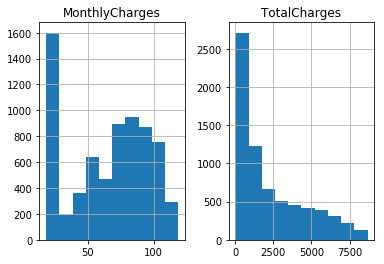

```python
data.hist(column = ['TotalCharges', 'MonthlyCharges'])
```

#### From the histogram, the TotalChages seems has a long tail distribution with right-skewed

```python
data[['TotalCharges', 'MonthlyCharges']].describe()
```

|  | TotalCharges | MonthlyCharges |
| --- | --- | --- |
| count | 7032.000000 | 7032.000000 |
| mean | 2283.300441 | 64.798208 |
| std | 2266.771362 | 30.085974 |
| min | 18.800000 | 18.250000 |
| 25% | 401.450000 | 35.587500 |
| 50% | 1397.475000 | 70.350000 |
| 75% | 3794.737500 | 89.862500 |
| max | 8684.800000 | 118.750000 |

#### The TotalCharges has a hight standard devitation, now we try to look at the boxplot by Churn to identify the outliers.

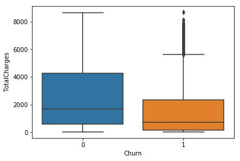

```python
figure = plt.figure()
ax = sns.boxplot(x='Churn', y='TotalCharges', data=data)
```

#### Churned customers has a lower median in TotalCharges than Non-Churned customers.

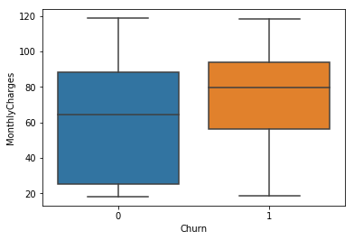

```python
figure = plt.figure()
ax = sns.boxplot(x='Churn', y='MonthlyCharges', data=data)
```

#### Churned customers has a higer median in MonthlyCharges than Non-Churned customers.

#### Try IQR to remove the outliers if any.

```python
def subset_by_iqr(df, column, whisker_width=1.5):
    """Remove outliers from a dataframe by column, including optional
       whiskers, removing rows for which the column value are
       less than Q1-1.5IQR or greater than Q3+1.5IQR.
    Args:
        df (`:obj:pd.DataFrame`): A pandas dataframe to subset
        column (str): Name of the column to calculate the subset from.
        whisker_width (float): Optional, loosen the IQR filter by a
                               factor of `whisker_width` * IQR.
    Returns:
        (`:obj:pd.DataFrame`): Filtered dataframe
    """
    # Calculate Q1, Q2 and IQR
    q1 = df[column].quantile(0.25)
    q3 = df[column].quantile(0.75)
    iqr = q3 - q1
    # Apply filter with respect to IQR, including optional whiskers
    filter = (df[column] >= q1 - whisker_width*iqr) & (df[column] <= q3 + whisker_width*iqr)
    return df.loc[filter]

data_filtered = subset_by_iqr(data, 'TotalCharges', whisker_width=1.5)
data_filtered = subset_by_iqr(data_filtered, 'MonthlyCharges', whisker_width=1.5)
```

```python
print('Total Rows and columns before removing outliers by IQR:')
print ("Rows     : " ,data.shape[0])
print('-----------------------------------------------------------------------------------------------------------------------')
print('Total Rows and columns after removing missing:')
print ("Rows     : " ,data_filtered.shape[0])
```

```
Total Rows and columns before removing outliers by IQR:
Rows     :  7032
-----------------------------------------------------------------------------------------------------------------------
Total Rows and columns after removing missing:
Rows     :  7032
```

#### It seems there is no extreme cases in our dataset, which are good for modeling.

#### Then try to scale the TotalCharges and MonthlyCharge bacauese of there high STD.

```python
std = StandardScaler()
scaled = std.fit_transform(data[num_cols])
scaled = pd.DataFrame(scaled,columns=num_cols)
```

```python
data_raw = data.copy()
data = data_raw.drop(columns = num_cols,axis = 1)
data = data.merge(scaled,left_index=True,right_index=True,how = "left")
```

```python
data[['TotalCharges', 'MonthlyCharges']].describe()
```

|  | TotalCharges | MonthlyCharges |
| --- | --- | --- |
| count | 7.032000e+03 | 7.032000e+03 |
| mean | -1.172113e-16 | 9.652878e-17 |
| std | 1.000071e+00 | 1.000071e+00 |
| min | -9.990692e-01 | -1.547283e+00 |
| 25% | -8.302488e-01 | -9.709769e-01 |
| 50% | -3.908151e-01 | 1.845440e-01 |
| 75% | 6.668271e-01 | 8.331482e-01 |
| max | 2.824261e+00 | 1.793381e+00 |

#### Data preprocessing finished, dataset are ready to go for modeling!!

## 3. Summary the dataset before modeling

- Show all the features
- Summarise all the features
- Correlation plot for all the features

```python
#List all the columns
data.columns
```

```
Index(['customerID', 'gender', 'SeniorCitizen', 'Partner', 'Dependents',
       'PhoneService', 'PaperlessBilling', 'Churn', 'MultipleLines_No',
       'MultipleLines_No_phone_service', 'MultipleLines_Yes',
       'InternetService_DSL', 'InternetService_Fiber_optic',
       'InternetService_No', 'OnlineSecurity_No',
       'OnlineSecurity_No_internet_service', 'OnlineSecurity_Yes',
       'OnlineBackup_No', 'OnlineBackup_No_internet_service',
       'OnlineBackup_Yes', 'DeviceProtection_No',
       'DeviceProtection_No_internet_service', 'DeviceProtection_Yes',
       'TechSupport_No', 'TechSupport_No_internet_service', 'TechSupport_Yes',
       'StreamingTV_No', 'StreamingTV_No_internet_service', 'StreamingTV_Yes',
       'StreamingMovies_No', 'StreamingMovies_No_internet_service',
       'StreamingMovies_Yes', 'Contract_Month_to_month', 'Contract_One_year',
       'Contract_Two_year', 'PaymentMethod_Bank_transfer_automatic_',
       'PaymentMethod_Credit_card_automatic_',
       'PaymentMethod_Electronic_check', 'PaymentMethod_Mailed_check',
       'tenure_group_tenure_group1', 'tenure_group_tenure_group2',
       'tenure_group_tenure_group3', 'tenure_group_tenure_group4',
       'tenure_group_tenure_group5', 'monthly_group_monthly_Q1',
       'monthly_group_monthly_Q2', 'monthly_group_monthly_Q3',
       'monthly_group_monthly_Q4', 'total_group_total_Q1',
       'total_group_total_Q2', 'total_group_total_Q3', 'total_group_total_Q4',
       'tenure', 'MonthlyCharges', 'TotalCharges'],
      dtype='object')
```

```python
#Summarise the features
data.describe()
```

|  | gender | SeniorCitizen | Partner | Dependents | PhoneService | PaperlessBilling | Churn | MultipleLines_No | MultipleLines_No_phone_service | MultipleLines_Yes | ... | monthly_group_monthly_Q2 | monthly_group_monthly_Q3 | monthly_group_monthly_Q4 | total_group_total_Q1 | total_group_total_Q2 | total_group_total_Q3 | total_group_total_Q4 | tenure | MonthlyCharges | TotalCharges |
| --- | --- | --- | --- | --- | --- | --- | --- | --- | --- | --- | --- | --- | --- | --- | --- | --- | --- | --- | --- | --- | --- |
| count | 7032.000000 | 7032.000000 | 7032.000000 | 7032.000000 | 7032.000000 | 7032.000000 | 7032.000000 | 7032.000000 | 7032.000000 | 7032.000000 | ... | 7032.000000 | 7032.000000 | 7032.000000 | 7032.000000 | 7032.000000 | 7032.000000 | 7032.000000 | 7.032000e+03 | 7.032000e+03 | 7.032000e+03 |
| mean | 0.495307 | 0.162400 | 0.482509 | 0.298493 | 0.903299 | 0.592719 | 0.265785 | 0.481371 | 0.096701 | 0.421928 | ... | 0.250427 | 0.249573 | 0.250000 | 0.250000 | 0.250000 | 0.250000 | 0.250000 | -1.214741e-16 | 9.652878e-17 | -1.172113e-16 |
| std | 0.500014 | 0.368844 | 0.499729 | 0.457629 | 0.295571 | 0.491363 | 0.441782 | 0.499688 | 0.295571 | 0.493902 | ... | 0.433290 | 0.432797 | 0.433043 | 0.433043 | 0.433043 | 0.433043 | 0.433043 | 1.000071e+00 | 1.000071e+00 | 1.000071e+00 |
| min | 0.000000 | 0.000000 | 0.000000 | 0.000000 | 0.000000 | 0.000000 | 0.000000 | 0.000000 | 0.000000 | 0.000000 | ... | 0.000000 | 0.000000 | 0.000000 | 0.000000 | 0.000000 | 0.000000 | 0.000000 | -1.280248e+00 | -1.547283e+00 | -9.990692e-01 |
| 25% | 0.000000 | 0.000000 | 0.000000 | 0.000000 | 1.000000 | 0.000000 | 0.000000 | 0.000000 | 0.000000 | 0.000000 | ... | 0.000000 | 0.000000 | 0.000000 | 0.000000 | 0.000000 | 0.000000 | 0.000000 | -9.542963e-01 | -9.709769e-01 | -8.302488e-01 |
| 50% | 0.000000 | 0.000000 | 0.000000 | 0.000000 | 1.000000 | 1.000000 | 0.000000 | 0.000000 | 0.000000 | 0.000000 | ... | 0.000000 | 0.000000 | 0.000000 | 0.000000 | 0.000000 | 0.000000 | 0.000000 | -1.394171e-01 | 1.845440e-01 | -3.908151e-01 |
| 75% | 1.000000 | 0.000000 | 1.000000 | 1.000000 | 1.000000 | 1.000000 | 1.000000 | 1.000000 | 0.000000 | 1.000000 | ... | 1.000000 | 0.000000 | 0.250000 | 0.250000 | 0.250000 | 0.250000 | 0.250000 | 9.199259e-01 | 8.331482e-01 | 6.668271e-01 |
| max | 1.000000 | 1.000000 | 1.000000 | 1.000000 | 1.000000 | 1.000000 | 1.000000 | 1.000000 | 1.000000 | 1.000000 | ... | 1.000000 | 1.000000 | 1.000000 | 1.000000 | 1.000000 | 1.000000 | 1.000000 | 1.612573e+00 | 1.793381e+00 | 2.824261e+00 |

8 rows × 54 columns

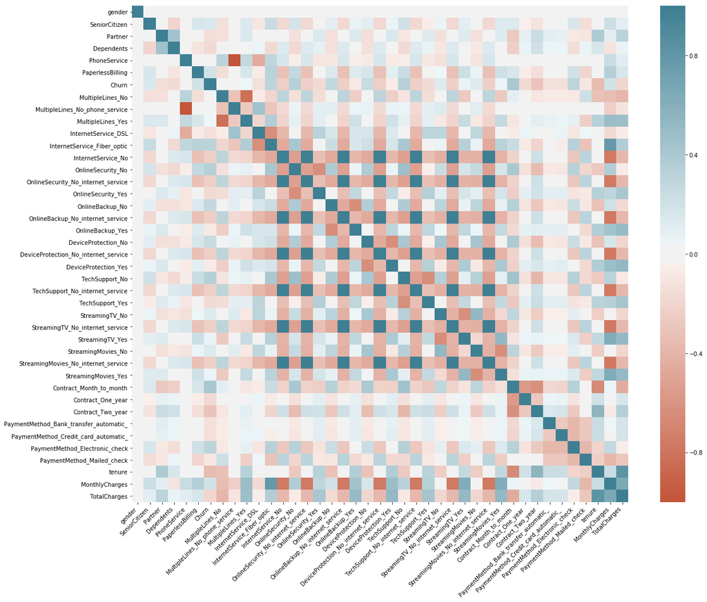

```python
#Correlation Plot
cor = data.drop(columns = ['customerID','tenure_group_tenure_group1', 'tenure_group_tenure_group2',
                            'tenure_group_tenure_group3', 'tenure_group_tenure_group4',
                            'tenure_group_tenure_group5', 'monthly_group_monthly_Q1',
                            'monthly_group_monthly_Q2', 'monthly_group_monthly_Q3',
                            'monthly_group_monthly_Q4', 'total_group_total_Q1',
                            'total_group_total_Q2', 'total_group_total_Q3', 'total_group_total_Q4'])
corr = cor.corr()
figure = plt.figure(figsize = (20,16))
ax = sns.heatmap(
    corr,
    vmin=-1, vmax=1, center=0,
    cmap=sns.diverging_palette(20, 220, n=200),
    square=True
)
ax.set_xticklabels(
    ax.get_xticklabels(),
    rotation=45,
    horizontalalignment='right'
);
```

## Build Models

### 1. Understand the target distribution

```
Class 0:  5163
Class 1:  1869
Proportion:  2.76 : 1
```

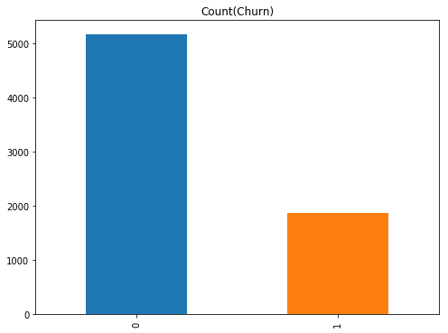

```python
#Understand the target variable
target_count =data['Churn'].value_counts()
print("Class 0: ", target_count[0])
print("Class 1: ", target_count[1])
print("Proportion: ", round(target_count[0]/target_count[1], 2) ,': 1')
figure = plt.figure(figsize = (8,6))
data['Churn'].value_counts().plot(kind = 'bar', title = 'Count(Churn)')
```

### 2. Split the dataset into Training and Testing set

```python
# Split the database into training and testing set
df = data.drop(['customerID', 'Churn'], axis = 1)
df_target = data['Churn']
X_train, X_test, y_train, y_test = train_test_split(df, df_target, test_size=0.2)
print('X Train shape is : ', X_train.shape)
print('Y Train shape is : ', y_train.shape)
print('X Test shape is: ', X_test.shape)
print('Y Test shape is: ', y_test.shape)
```

```
X Train shape is :  (5625, 53)
Y Train shape is :  (5625,)
X Test shape is:  (1407, 53)
Y Test shape is:  (1407,)
```

### 3. Baseline Model (Logistic Regression)

#### 3.1 Report the baseline model performance

```
Accuracy: 79.18%
Confusion matrix:
 [[913 118]
 [175 201]]
```

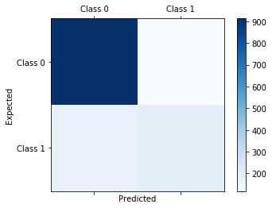

```
              precision    recall  f1-score   support

           0       0.84      0.89      0.86      1031
           1       0.63      0.53      0.58       376

   micro avg       0.79      0.79      0.79      1407
   macro avg       0.73      0.71      0.72      1407
weighted avg       0.78      0.79      0.79      1407
```

```python
#1. Model parameters
model1 = linear_model.LogisticRegression(C=1.0, penalty='l1', tol=1e-6)
model1.fit(X_train, y_train)

#2. Accuracy score on testing set
y_pred = model1.predict(X_test)
accuracy = accuracy_score(y_test, y_pred)
print("Accuracy: %.2f%%" % (accuracy * 100.0))

#3. Confusion matrix
conf_mat = confusion_matrix(y_true=y_test, y_pred=y_pred)
print('Confusion matrix:\n', conf_mat)

labels = ['Class 0', 'Class 1']
fig = plt.figure()
ax = fig.add_subplot(111)
cax = ax.matshow(conf_mat, cmap=plt.cm.Blues)
fig.colorbar(cax)
ax.set_xticklabels([''] + labels)
ax.set_yticklabels([''] + labels)
plt.xlabel('Predicted')
plt.ylabel('Expected')
plt.show()

#4. Classification report
report = classification_report(y_test, y_pred)
print(report)
```

#### 3.2 Report the feature importance

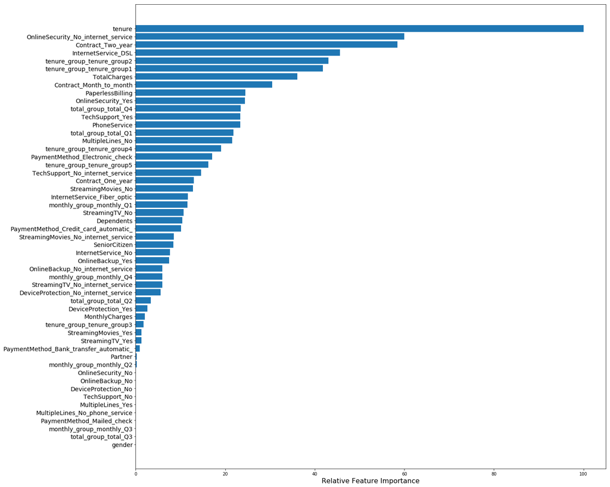

```python
feature_importance = abs(model1.coef_[0])
feature_importance = 100.0 * (feature_importance / feature_importance.max())
sorted_idx = np.argsort(feature_importance)
pos = np.arange(sorted_idx.shape[0]) + .5

featfig = plt.figure(figsize = (20,16))
featax = featfig.add_subplot(1, 1, 1)
featax.barh(pos, feature_importance[sorted_idx], align='center')
featax.set_yticks(pos)
featax.set_yticklabels(np.array(X_train.columns)[sorted_idx], fontsize=14)
featax.set_xlabel('Relative Feature Importance', fontsize=16)

plt.tight_layout()
plt.show()
```

#### 3.3 Report the feature coefs

```python
#2. Get coef of features
pd.DataFrame({"columns":list(X_train.columns), "coef":list(model1.coef_.T)})
```

|  | columns | coef |
| --- | --- | --- |
| 0 | gender | [0.0] |
| 1 | SeniorCitizen | [0.12978610907220295] |
| 2 | Partner | [-0.0036821322078942377] |
| 3 | Dependents | [-0.16076819395877123] |
| 4 | PhoneService | [-0.3614061622445407] |
| 5 | PaperlessBilling | [0.3794468407293843] |
| 6 | MultipleLines_No | [-0.33327848201977395] |
| 7 | MultipleLines_No_phone_service | [0.0] |
| 8 | MultipleLines_Yes | [0.0] |
| 9 | InternetService_DSL | [-0.7052997737343292] |
| 10 | InternetService_Fiber_optic | [0.1803396486459007] |
| 11 | InternetService_No | [-0.11913374896048452] |
| 12 | OnlineSecurity_No | [1.6363321808541946e-08] |
| 13 | OnlineSecurity_No_internet_service | [-0.9281437709002508] |
| 14 | OnlineSecurity_Yes | [-0.3779839351982487] |
| 15 | OnlineBackup_No | [0.0] |
| 16 | OnlineBackup_No_internet_service | [-0.0922759827354802] |
| 17 | OnlineBackup_Yes | [-0.11514976133208149] |
| 18 | DeviceProtection_No | [0.0] |
| 19 | DeviceProtection_No_internet_service | [-0.08593787318967375] |
| 20 | DeviceProtection_Yes | [-0.040771011217680696] |
| 21 | TechSupport_No | [0.0] |
| 22 | TechSupport_No_internet_service | [-0.22565629589168232] |
| 23 | TechSupport_Yes | [-0.3620816711357566] |
| 24 | StreamingTV_No | [-0.16598063401620564] |
| 25 | StreamingTV_No_internet_service | [-0.0914098527293715] |
| 26 | StreamingTV_Yes | [0.020072276209703165] |
| 27 | StreamingMovies_No | [-0.19813883407443972] |
| 28 | StreamingMovies_No_internet_service | [-0.13240779150451365] |
| 29 | StreamingMovies_Yes | [0.02031385827558031] |
| 30 | Contract_Month_to_month | [0.47215883610554515] |
| 31 | Contract_One_year | [-0.2003599610691522] |
| 32 | Contract_Two_year | [-0.9046139816109393] |
| 33 | PaymentMethod_Bank_transfer_automatic_ | [-0.014367488549181488] |
| 34 | PaymentMethod_Credit_card_automatic_ | [-0.15657675698208154] |
| 35 | PaymentMethod_Electronic_check | [0.26426566391341966] |
| 36 | PaymentMethod_Mailed_check | [0.0] |
| 37 | tenure_group_tenure_group1 | [-0.6471325355110032] |
| 38 | tenure_group_tenure_group2 | [-0.6664686487267611] |
| 39 | tenure_group_tenure_group3 | [-0.026673664768989285] |
| 40 | tenure_group_tenure_group4 | [0.2952255871809234] |
| 41 | tenure_group_tenure_group5 | [0.25033830035559196] |
| 42 | monthly_group_monthly_Q1 | [-0.17913860494901734] |
| 43 | monthly_group_monthly_Q2 | [-0.00329710652505914] |
| 44 | monthly_group_monthly_Q3 | [0.0] |
| 45 | monthly_group_monthly_Q4 | [0.09166590663634205] |
| 46 | total_group_total_Q1 | [0.33820215181596724] |
| 47 | total_group_total_Q2 | [-0.05263588729966564] |
| 48 | total_group_total_Q3 | [0.0] |
| 49 | total_group_total_Q4 | [-0.36337084147938237] |
| 50 | tenure | [-1.5469524028629538] |
| 51 | MonthlyCharges | [0.03160213693983338] |
| 52 | TotalCharges | [0.5589558099534407] |

#### 3.4 Report the learning curve(to see whether there are any overfittings)

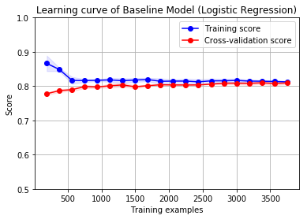

```
(0.8103209015332382, 0.010265870280757317)
```

```python
#Report the learning curve
def plot_learning_curve(estimator, title, X, y, ylim=None, cv=None, n_jobs=1,
                        train_sizes=np.linspace(.05, 1., 20), verbose=0, plot=True):
    """
    Plot learning curve of applied data model.
    ----------
    estimator : Classification
    title : title of plot
    X : features in numpy
    y : tearget in matrix
    ylim : tuple with (ymin, ymax)
    cv : cross-validation fold default as 3
    n_jobs :
    """
    train_sizes, train_scores, test_scores = learning_curve(
        estimator, X, y, cv=cv, n_jobs=n_jobs, train_sizes=train_sizes, verbose=verbose)

    train_scores_mean = np.mean(train_scores, axis=1)
    train_scores_std = np.std(train_scores, axis=1)
    test_scores_mean = np.mean(test_scores, axis=1)
    test_scores_std = np.std(test_scores, axis=1)

    if plot:
        plt.figure()
        plt.title(title)
        if ylim is not None:
            plt.ylim(*ylim)
        plt.xlabel(u"Training examples")
        plt.ylabel(u"Score")
        plt.gca().invert_yaxis()
        plt.grid()

        plt.fill_between(train_sizes, train_scores_mean - train_scores_std, train_scores_mean + train_scores_std,
                         alpha=0.1, color="b")
        plt.fill_between(train_sizes, test_scores_mean - test_scores_std, test_scores_mean + test_scores_std,
                         alpha=0.1, color="r")
        plt.plot(train_sizes, train_scores_mean, 'o-', color="b", label=u"Training score")
        plt.plot(train_sizes, test_scores_mean, 'o-', color="r", label=u"Cross-validation score")

        plt.legend(loc="best")

        plt.draw()
        plt.gca().invert_yaxis()
        plt.show()

    midpoint = ((train_scores_mean[-1] + train_scores_std[-1]) + (test_scores_mean[-1] - test_scores_std[-1])) / 2
    diff = (train_scores_mean[-1] + train_scores_std[-1]) - (test_scores_mean[-1] - test_scores_std[-1])
    return midpoint, diff

#plot_learning_curve(clf_under, u"leraning curve", X, y)
plot_learning_curve(model1, u"Learning curve of Baseline Model (Logistic Regression)", X_train, y_train, ylim = [0.5,1])
```

### 4. Other Models

#### 4.1 Report other models performance

```python
cv = ShuffleSplit(n_splits = 3, test_size=0.2,random_state=0)
print ("Model1: Logistic Regression(BaseLine)")
for train, test in cv.split(X_train):
    model1 = linear_model.LogisticRegression(C=1.0, penalty='l1', tol=1e-6).fit(X_train, y_train)
    print("train score: {0:.3f}, test score: {1:.3f}\n".format(
        model1.score(X_train, y_train), model1.score(X_test, y_test)))
print('-----------------------------------------------------------------------------------------------------------------------')
print ("Model2: Ridge Classifier" )
for train, test in cv.split(X_train):
    model2 = linear_model.RidgeClassifier().fit(X_train, y_train)
    print("train score: {0:.3f}, test score: {1:.3f}\n".format(
        model2.score(X_train, y_train), model2.score(X_test, y_test)))
print('-----------------------------------------------------------------------------------------------------------------------')
print ("Model3: SVC(kernel='rbf')")
for train, test in cv.split(X_train):
    model3 = svm.SVC(kernel ='rbf').fit(X_train, y_train)
    print("train score: {0:.3f}, test score: {1:.3f}\n".format(
        model3.score(X_train, y_train), model3.score(X_test, y_test)))
print('-----------------------------------------------------------------------------------------------------------------------')
print ("Model4: Gradient Boosting"  )
for train, test in cv.split(X_train):
    model4 = GradientBoostingClassifier().fit(X_train, y_train)
    print("train score: {0:.3f}, test score: {1:.3f}\n".format(
        model4.score(X_train, y_train), model4.score(X_test, y_test)))
print('-----------------------------------------------------------------------------------------------------------------------')
print ("Model5: Random Forest ()"  )
for train, test in cv.split(X_train):
    model5 = RandomForestClassifier().fit(X_train, y_train)
    print("train score: {0:.3f}, test score: {1:.3f}\n".format(
        model5.score(X_train, y_train), model5.score(X_test, y_test)))
print('-----------------------------------------------------------------------------------------------------------------------')
print("Model6: XGboost ()")
for train, test in cv.split(X_train):
    model6 = XGBClassifier().fit(X_train, y_train)
    print("train score: {0:.3f}, test score: {1:.3f}\n".format(
        model6.score(X_train, y_train), model6.score(X_test, y_test)))
```

```
Model1: Logistic Regression(BaseLine)
train score: 0.812, test score: 0.792

train score: 0.812, test score: 0.792

train score: 0.812, test score: 0.792

-----------------------------------------------------------------------------------------------------------------------
Model2: Ridge Classifier
train score: 0.805, test score: 0.795

train score: 0.805, test score: 0.795

train score: 0.805, test score: 0.795

-----------------------------------------------------------------------------------------------------------------------
Model3: SVC(kernel='rbf')
train score: 0.804, test score: 0.789

train score: 0.804, test score: 0.789

train score: 0.804, test score: 0.789

-----------------------------------------------------------------------------------------------------------------------
Model4: Gradient Boosting
train score: 0.829, test score: 0.799

train score: 0.829, test score: 0.799

train score: 0.829, test score: 0.799

-----------------------------------------------------------------------------------------------------------------------
Model5: Random Forest ()
train score: 0.982, test score: 0.765

train score: 0.981, test score: 0.769

train score: 0.981, test score: 0.764

-----------------------------------------------------------------------------------------------------------------------
Model6: XGboost ()
train score: 0.823, test score: 0.797

train score: 0.823, test score: 0.797

train score: 0.823, test score: 0.797
```

#### 4.2 Report the comparsion of default other models

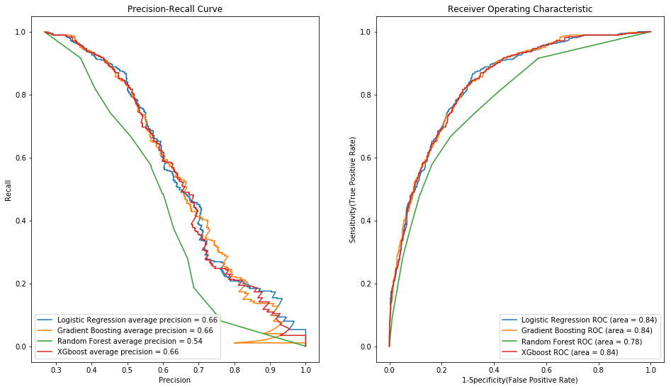

```python
fig, (ax1, ax2) = plt.subplots(1,2,figsize = (16,9))

# Add the models to the list that you want to view on the ROC plot
models = [
{
    'label': 'Logistic Regression',
    'model': linear_model.LogisticRegression(C=1.0, penalty='l1', tol=1e-6),
},
{
    'label': 'Gradient Boosting',
    'model': GradientBoostingClassifier(),
},
{
    'label': 'Random Forest',
    'model': RandomForestClassifier(),
},
{
    'label': 'XGboost',
    'model': XGBClassifier()
}
]

# Below for loop iterates through your models list
for m in models:
    model = m['model'] # select the model
    model.fit(X_train, y_train) # train the model
    y_pred=model.predict(X_test) # predict the test data

    #precision-recall curve
    precision, recall, thresholds_pr = precision_recall_curve(y_test, model.predict_proba(X_test)[:,1])
    avg_pre = average_precision_score(y_test, model.predict_proba(X_test)[:,1])
    ax1.plot(precision, recall, label = '%s average precision = %0.2f'%(m['label'], avg_pre))
    #ax1.plot([0, 1], [0, 1],'r--')
    #ax1.xlim([0.0, 1.0])
    #ax1.ylim([0.0, 1.05])
    ax1.set_xlabel('Precision')
    ax1.set_ylabel('Recall')
    ax1.set_title('Precision-Recall Curve')
    ax1.legend(loc = 'lower left')

    #ROC curve
    fpr, tpr, thresholds = metrics.roc_curve(y_test, model.predict_proba(X_test)[:,1])
    auc = metrics.roc_auc_score(y_test,model.predict_proba(X_test)[:,1])
    ax2.plot(fpr, tpr, label='%s ROC (area = %0.2f)' % (m['label'], auc))
    #ax2.plot([0, 1], [0, 1],'r--')
    #ax2.xlim([0.0, 1.0])
    #ax2.ylim([0.0, 1.05])
    ax2.set_xlabel('1-Specificity(False Positive Rate)')
    ax2.set_ylabel('Sensitivity(True Positive Rate)')
    ax2.set_title('Receiver Operating Characteristic')
    ax2.legend(loc="lower right")
plt.show()   # Display
```

#### Here, I would like to choose Xgboost to go further with parameter tunning

### 5. Xgboost parameter tunning

#### Tunning 1: n_estimators

```python
param_test1 = {
 'n_estimators':[50,100,150,200,250],
}
gsearch1 = GridSearchCV(estimator = XGBClassifier(learning_rate =0.1, n_estimators=140,
 objective= 'binary:logistic', nthread=4, scale_pos_weight=1, seed=27),
 param_grid = param_test1, scoring='accuracy',n_jobs=4,iid=False, cv=5)
gsearch1.fit(X_train,y_train)
gsearch1.best_params_, gsearch1.best_score_
```

```
({'n_estimators': 50}, 0.806757485565311)
```

```python
param_test1 = {
 'n_estimators':[20,40,50,60,80],
}
gsearch1 = GridSearchCV(estimator = XGBClassifier( learning_rate =0.1, n_estimators=140,
 objective= 'binary:logistic', nthread=4, scale_pos_weight=1, seed=27),
 param_grid = param_test1, scoring='accuracy',n_jobs=4,iid=False, cv=5)
gsearch1.fit(X_train,y_train)
gsearch1.best_params_, gsearch1.best_score_
```

```
({'n_estimators': 60}, 0.8085336839377255)
```

#### Result: n_estimators = 60

```
Accuracy: 79.96%
Confusion matrix:
 [[928 103]
 [179 197]]
```

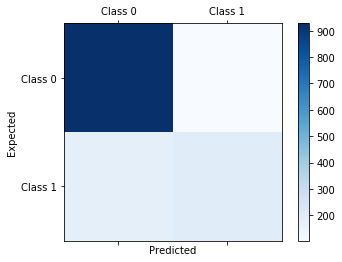

```
              precision    recall  f1-score   support

           0       0.84      0.90      0.87      1031
           1       0.66      0.52      0.58       376

   micro avg       0.80      0.80      0.80      1407
   macro avg       0.75      0.71      0.73      1407
weighted avg       0.79      0.80      0.79      1407
```

```python
#1. Model6: Xgboost with n_estimators = 60
model6_xbg1 = XGBClassifier(
 learning_rate =0.1,
 n_estimators=60,
 objective= 'binary:logistic', nthread=4, scale_pos_weight=1, seed=27
)
model6_xbg1.fit(X_train, y_train)

#2. Accuracy score on testing set
y_pred = model6_xbg1.predict(X_test)
accuracy = accuracy_score(y_test, y_pred)
print("Accuracy: %.2f%%" % (accuracy * 100.0))

#3. Confusion matrix
conf_mat = confusion_matrix(y_true=y_test, y_pred=y_pred)
print('Confusion matrix:\n', conf_mat)

labels = ['Class 0', 'Class 1']
fig = plt.figure()
ax = fig.add_subplot(111)
cax = ax.matshow(conf_mat, cmap=plt.cm.Blues)
fig.colorbar(cax)
ax.set_xticklabels([''] + labels)
ax.set_yticklabels([''] + labels)
plt.xlabel('Predicted')
plt.ylabel('Expected')
plt.show()

#4. Classification report
report = classification_report(y_test, y_pred)
print(report)
```

#### Tuning 2: max_depth & min_child_weight

```python
param_test2 = {
 'max_depth':range(3,10,1),
 'min_child_weight':range(1,6,1)
}
gsearch2 = GridSearchCV(estimator = XGBClassifier( learning_rate =0.1, n_estimators=60,
 objective= 'binary:logistic', nthread=4, scale_pos_weight=1, seed=27),
 param_grid = param_test2, scoring='accuracy',n_jobs=4,iid=False, cv=5)
gsearch2.fit(X_train,y_train)
gsearch2.best_params_, gsearch2.best_score_
```

```
({'max_depth': 3, 'min_child_weight': 1}, 0.8085336839377255)
```

#### Result: max_depth = 3 and min_child_weight = 1

```
Accuracy: 79.96%
Confusion matrix:
 [[928 103]
 [179 197]]
```

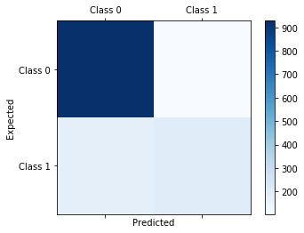

```
              precision    recall  f1-score   support

           0       0.84      0.90      0.87      1031
           1       0.66      0.52      0.58       376

   micro avg       0.80      0.80      0.80      1407
   macro avg       0.75      0.71      0.73      1407
weighted avg       0.79      0.80      0.79      1407
```

```python
#1. Model6: Xgboost with n_estimators = 60, max_depth = 3 and min_child_weight = 1
model6_xbg2 = XGBClassifier(
  learning_rate =0.1,
  max_depth = 3,
  min_child_weight = 1,
  n_estimators=60,
  objective= 'binary:logistic', nthread=4, scale_pos_weight=1, seed=27
)
model6_xbg2.fit(X_train, y_train)

#2. Accuracy score on testing set
y_pred = model6_xbg2.predict(X_test)
accuracy = accuracy_score(y_test, y_pred)
print("Accuracy: %.2f%%" % (accuracy * 100.0))

#3. Confusion matrix
conf_mat = confusion_matrix(y_true=y_test, y_pred=y_pred)
print('Confusion matrix:\n', conf_mat)

labels = ['Class 0', 'Class 1']
fig = plt.figure()
ax = fig.add_subplot(111)
cax = ax.matshow(conf_mat, cmap=plt.cm.Blues)
fig.colorbar(cax)
ax.set_xticklabels([''] + labels)
ax.set_yticklabels([''] + labels)
plt.xlabel('Predicted')
plt.ylabel('Expected')
plt.show()

#4. Classification report
report = classification_report(y_test, y_pred)
print(report)
```

#### Tunning 3: Gamma

```python
param_test3 = {
 'gamma':[i/10.0 for i in range(0,5)]
}
gsearch3 = GridSearchCV(estimator = XGBClassifier( learning_rate =0.1, n_estimators=60, max_depth=3,
 min_child_weight=1,
 objective= 'binary:logistic', nthread=4, scale_pos_weight=1, seed=27),
 param_grid = param_test3, scoring='accuracy',n_jobs=4,iid=False, cv=5)
gsearch3.fit(X_train,y_train)
gsearch3.best_params_, gsearch3.best_score_
```

```
({'gamma': 0.0}, 0.8085336839377255)
```

#### Result: socre no improved, keep it as default

#### Tunning 4 : subsample and colsample_bytree

```python
param_test4 = {
 'subsample':[i/10.0 for i in range(6,10)],
 'colsample_bytree':[i/10.0 for i in range(6,10)]
}
gsearch4 = GridSearchCV(estimator = XGBClassifier( learning_rate =0.1, n_estimators=60, max_depth=3,
 min_child_weight=1,
 objective= 'binary:logistic', nthread=4, scale_pos_weight=1, seed=27),
 param_grid = param_test4, scoring='accuracy',n_jobs=4,iid=False, cv=5)
gsearch4.fit(X_train,y_train)
gsearch4.best_params_, gsearch4.best_score_
```

```
({'colsample_bytree': 0.9, 'subsample': 0.7}, 0.8092474821730449)
```

#### Result: colsample_bytree = 0.9 and subsample = 0.7

```
Accuracy: 80.31%
Confusion matrix:
 [[925 106]
 [171 205]]
```

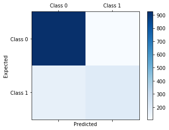

```
              precision    recall  f1-score   support

           0       0.84      0.90      0.87      1031
           1       0.66      0.55      0.60       376

   micro avg       0.80      0.80      0.80      1407
   macro avg       0.75      0.72      0.73      1407
weighted avg       0.79      0.80      0.80      1407
```

```python
#1. Model6: Xgboost with
# n_estimators = 60,
# max_depth = 3 and min_child_weight = 1
# colsample_bytree = 0.9, subsample = 0.7
model6_xbg3 = XGBClassifier(
  learning_rate =0.1,
  max_depth = 3,
  min_child_weight = 1,
  n_estimators=60,
  colsample_bytree = 0.9,
  subsample = 0.7,
  objective= 'binary:logistic', nthread=4, scale_pos_weight=1, seed=27
)
model6_xbg3.fit(X_train, y_train)

#2. Accuracy score on testing set
y_pred = model6_xbg3.predict(X_test)
accuracy = accuracy_score(y_test, y_pred)
print("Accuracy: %.2f%%" % (accuracy * 100.0))

#3. Confusion matrix
conf_mat = confusion_matrix(y_true=y_test, y_pred=y_pred)
print('Confusion matrix:\n', conf_mat)

labels = ['Class 0', 'Class 1']
fig = plt.figure()
ax = fig.add_subplot(111)
cax = ax.matshow(conf_mat, cmap=plt.cm.Blues)
fig.colorbar(cax)
ax.set_xticklabels([''] + labels)
ax.set_yticklabels([''] + labels)
plt.xlabel('Predicted')
plt.ylabel('Expected')
plt.show()

#4. Classification report
report = classification_report(y_test, y_pred)
print(report)
```

#### Tunning 5: reg_lambda

```python
param_test5 = {
 'reg_lambda':[1e-5, 1e-2, 0.1, 0.4, 0.8, 1,1.2, 1.6, 100]
}

gsearch5 = GridSearchCV(estimator = XGBClassifier( learning_rate =0.1, n_estimators=60,
 max_depth=3, min_child_weight=1,
 colsample_bytree = 0.9, subsample = 0.7,
 objective= 'binary:logistic', nthread=4, scale_pos_weight=1, seed=27),
 param_grid = param_test5, scoring='accuracy',n_jobs=4,iid=False, cv=5)
gsearch5.fit(X_train,y_train)
gsearch5.best_params_, gsearch5.best_score_
```

```
({'reg_lambda': 1}, 0.8092474821730449)
```

#### Result: score no imporvement, keep it as default

#### Tunning 6: reg_alpha

```python
param_test6 = {
 'reg_alpha':[0, 0.001, 0.005, 0.01, 0.05]
}

gsearch6 = GridSearchCV(estimator = XGBClassifier( learning_rate =0.1, n_estimators=60,
 max_depth=3, min_child_weight=1,
 colsample_bytree = 0.9, subsample = 0.7,
 objective= 'binary:logistic', nthread=4, scale_pos_weight=1, seed=27),
 param_grid = param_test6, scoring='accuracy',n_jobs=4,iid=False, cv=5)
gsearch6.fit(X_train,y_train)
gsearch6.best_params_, gsearch6.best_score_
```

```
({'reg_alpha': 0}, 0.8092474821730449)
```

#### Result: score no imporvment, keep it as default

#### Final Tuned XGboost model

```
Accuracy: 80.24%
Confusion matrix:
 [[924 107]
 [171 205]]
```

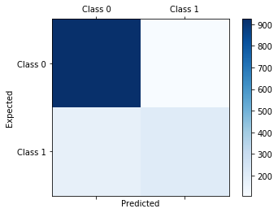

```
              precision    recall  f1-score   support

           0       0.84      0.90      0.87      1031
           1       0.66      0.55      0.60       376

   micro avg       0.80      0.80      0.80      1407
   macro avg       0.75      0.72      0.73      1407
weighted avg       0.79      0.80      0.80      1407
```

```python
#1. Model6: Xgboost with
# learning_rate =0.01
# n_estimators = 1000,
# max_depth = 3 and min_child_weight = 1
# colsample_bytree = 0.9, subsample = 0.7
model6_xbg4 = XGBClassifier(
  learning_rate =0.01,
  max_depth = 3,
  min_child_weight = 1,
  n_estimators=1000,
  colsample_bytree = 0.9,
  subsample = 0.7,
  objective= 'binary:logistic', nthread=4, scale_pos_weight=1, seed=27
)
model6_xbg4.fit(X_train, y_train)

#2. Accuracy score on testing set
y_pred = model6_xbg4.predict(X_test)
accuracy = accuracy_score(y_test, y_pred)
print("Accuracy: %.2f%%" % (accuracy * 100.0))

#3. Confusion matrix
conf_mat = confusion_matrix(y_true=y_test, y_pred=y_pred)
print('Confusion matrix:\n', conf_mat)

labels = ['Class 0', 'Class 1']
fig = plt.figure()
ax = fig.add_subplot(111)
cax = ax.matshow(conf_mat, cmap=plt.cm.Blues)
fig.colorbar(cax)
ax.set_xticklabels([''] + labels)
ax.set_yticklabels([''] + labels)
plt.xlabel('Predicted')
plt.ylabel('Expected')
plt.show()

#4. Classification report
report = classification_report(y_test, y_pred)
print(report)
```

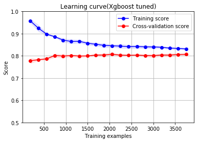

```
(0.8185654101796955, 0.03467506371699991)
```

```python
plot_learning_curve(model6_xbg4, u"Learning curve(Xgboost tuned)", X_train, y_train, ylim = [0.5,1])
```

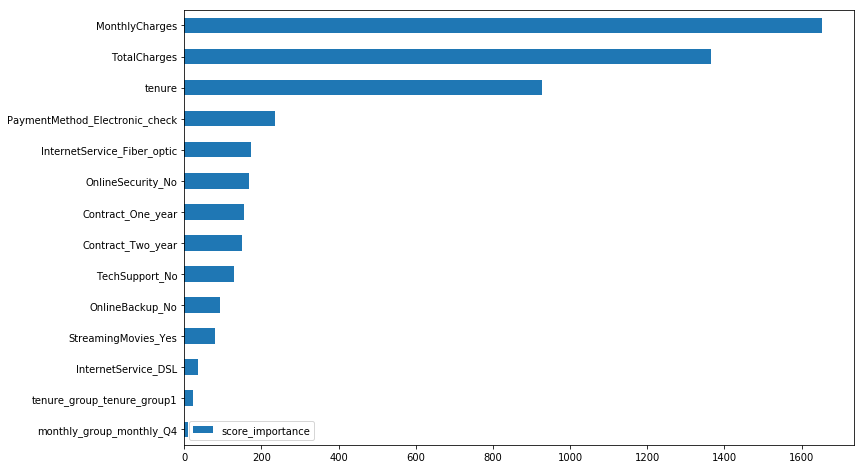

```python
feature_important = model6_xbg4.get_booster().get_score(importance_type='weight')
keys = list(feature_important.keys())
values = list(feature_important.values())

data_opp = pd.DataFrame(data=values[1:15], index=keys[1:15], columns=["score_importance"]).sort_values(by = "score_importance", ascending=True)
data_opp.plot(kind='barh', figsize = (12,8))
```

## Model in Reality

Consider about the business question, we should not only care about the accuracy of the model but also the Precision and Recall(Sensitivity).

- Precision: Of all the customers that we predicted as Churned, how many actually Churned?
- Recall(Sensitivity): Of all the customers that truly Churned, how many actually predicted as Churned?
- F1 score: F1 Score is the weighted average of Precision and Recall.

Here in this situation, the cost of false positive is lower than false negative. Which means that if a customer is actully churned, but the model predict it as Non-churned, it will be more harmful to the revenue than if a customer is actully Non-churned, but we predict it as Churned.

### XGboost weighted

The mian idea here is to add more weight for Churn in the loss function try to improve the F1 score

```python
weight_0 = np.where(y_train==0, 1, 1)
weight_1 = np.where(y_train==0, 1, 1.1)
weight_2 = np.where(y_train==0, 1, 1.2)
weight_3 = np.where(y_train==0, 1, 1.3)
weight_4 = np.where(y_train==0, 1, 1.4)
weight_5 = np.where(y_train==0, 1, 1.5)
weight_6 = np.where(y_train==0, 1, 1.6)
weight_7 = np.where(y_train==0, 1, 1.7)
weight_8 = np.where(y_train==0, 1, 1.8)
weight_9 = np.where(y_train==0, 1, 1.9)
```

```python
weights = [weight_0, weight_1, weight_2,weight_3, weight_4, weight_5, weight_6, weight_7, weight_8, weight_9]
i = 0
for weight in weights:
    model6_xbg4.fit(X_train, y_train, sample_weight = weight)
    y_pred = model6_xbg4.predict(X_test)
    accuracy = accuracy_score(y_test, y_pred)
    auc = roc_auc_score(y_test, y_pred)
    f1_score = metrics.f1_score(y_test, y_pred)
    precision_score = metrics.precision_score(y_test, y_pred)
    recall_score = metrics.recall_score(y_test, y_pred)
    print("Weight", i, end = '|')
    print("Accuracy : %.2f%%" % (accuracy * 100.0), end = '|')
    print("AUC Score: %.2f%%" % (auc * 100.0), end = '|')
    print("F1 Score : %.2f%%" % (f1_score * 100.0), end = '|')
    print("Precision: %.2f%%" % (precision_score * 100.0), end = '|')
    print("Recall   : %.2f%%" % (precision_score * 100.0))
    i = i+1
```

```
Weight 0|Accuracy : 80.24%|AUC Score: 72.07%|F1 Score : 59.59%|Precision: 65.71%|Recall   : 65.71%
Weight 1|Accuracy : 79.74%|AUC Score: 72.32%|F1 Score : 59.80%|Precision: 63.66%|Recall   : 63.66%
Weight 2|Accuracy : 78.96%|AUC Score: 72.72%|F1 Score : 60.11%|Precision: 60.93%|Recall   : 60.93%
Weight 3|Accuracy : 78.89%|AUC Score: 73.52%|F1 Score : 61.07%|Precision: 60.21%|Recall   : 60.21%
Weight 4|Accuracy : 78.18%|AUC Score: 73.54%|F1 Score : 60.89%|Precision: 58.44%|Recall   : 58.44%
Weight 5|Accuracy : 77.97%|AUC Score: 74.07%|F1 Score : 61.44%|Precision: 57.71%|Recall   : 57.71%
Weight 6|Accuracy : 77.90%|AUC Score: 75.03%|F1 Score : 62.48%|Precision: 57.17%|Recall   : 57.17%
Weight 7|Accuracy : 76.97%|AUC Score: 74.49%|F1 Score : 61.61%|Precision: 55.56%|Recall   : 55.56%
Weight 8|Accuracy : 76.69%|AUC Score: 74.80%|F1 Score : 61.86%|Precision: 54.96%|Recall   : 54.96%
Weight 9|Accuracy : 76.47%|AUC Score: 75.58%|F1 Score : 62.60%|Precision: 54.42%|Recall   : 54.42%
```

#### Here, choose weight_3 as final model

```
Accuracy: 78.89%
Confusion matrix:
 [[877 154]
 [143 233]]
```

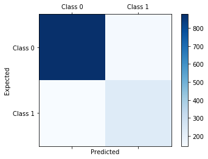

```
              precision    recall  f1-score   support

           0       0.86      0.85      0.86      1031
           1       0.60      0.62      0.61       376

   micro avg       0.79      0.79      0.79      1407
   macro avg       0.73      0.74      0.73      1407
weighted avg       0.79      0.79      0.79      1407
```

```python
model6_xbg4.fit(X_train, y_train, sample_weight = weight_3)

#2. Accuracy score on testing set
y_pred = model6_xbg4.predict(X_test)
accuracy = accuracy_score(y_test, y_pred)
print("Accuracy: %.2f%%" % (accuracy * 100.0))

#3. Confusion matrix
conf_mat = confusion_matrix(y_true=y_test, y_pred=y_pred)
print('Confusion matrix:\n', conf_mat)

labels = ['Class 0', 'Class 1']
fig = plt.figure()
ax = fig.add_subplot(111)
cax = ax.matshow(conf_mat, cmap=plt.cm.Blues)
fig.colorbar(cax)
ax.set_xticklabels([''] + labels)
ax.set_yticklabels([''] + labels)
plt.xlabel('Predicted')
plt.ylabel('Expected')
plt.show()

#4. Classification report
report = classification_report(y_test, y_pred)
print(report)
```

### Model Performance Comparsion

```python
model1.fit(X_train, y_train)
y_pred = model1.predict(X_test)
accuracy = accuracy_score(y_test, y_pred)
auc = roc_auc_score(y_test, y_pred)
f1_score = metrics.f1_score(y_test, y_pred)
precision_score = metrics.precision_score(y_test, y_pred)
recall_score = metrics.recall_score(y_test, y_pred)
print("Model1: BaseLine Model", end = ' |')
print("Accuracy : %.2f%%" % (accuracy * 100.0), end = ' |')
print("AUC Score: %.2f%%" % (auc * 100.0), end = ' |')
print("F1 Score : %.2f%%" % (f1_score * 100.0))

model6_xbg4.fit(X_train, y_train)
y_pred = model6_xbg4.predict(X_test)
accuracy = accuracy_score(y_test, y_pred)
auc = roc_auc_score(y_test, y_pred)
f1_score = metrics.f1_score(y_test, y_pred)
precision_score = metrics.precision_score(y_test, y_pred)
recall_score = metrics.recall_score(y_test, y_pred)
print("Model6: XGboost Tuned ",end = ' |')
print("Accuracy : %.2f%%" % (accuracy * 100.0), end = ' |')
print("AUC Score: %.2f%%" % (auc * 100.0), end = ' |')
print("F1 Score : %.2f%%" % (f1_score * 100.0))

model6_xbg4.fit(X_train, y_train,sample_weight = weight_3)
y_pred = model6_xbg4.predict(X_test)
accuracy = accuracy_score(y_test, y_pred)
auc = roc_auc_score(y_test, y_pred)
f1_score = metrics.f1_score(y_test, y_pred)
precision_score = metrics.precision_score(y_test, y_pred)
recall_score = metrics.recall_score(y_test, y_pred)
print("Model6: Final Model   ", end = ' |')
print("Accuracy : %.2f%%" % (accuracy * 100.0), end = ' |')
print("AUC Score: %.2f%%" % (auc * 100.0), end = ' |')
print("F1 Score : %.2f%%" % (f1_score * 100.0))
```

```
Model1: BaseLine Model |Accuracy : 79.18% |AUC Score: 71.01% |F1 Score : 57.84%
Model6: XGboost Tuned  |Accuracy : 80.24% |AUC Score: 72.07% |F1 Score : 59.59%
Model6: Final Model    |Accuracy : 78.89% |AUC Score: 73.52% |F1 Score : 61.07%
```

#### Although the total accuracy is slightly decreased, the AUC and F1 all incresed here. Consider about the truth that business cost of false positive is lower than false negative. We lost more if we predict a customer as Non-churned is actully churned. So, I would like to choose this weighted model as my final model!!